# ST661 R prog Assignment 2

Paul Williamson

07/11/2018

# QUESTION 1:

*Download the cdc1.Rdata file from moodle and load*

```r
load("C:/Users/PAUL/Documents/.Maynooth HDip/ST661 R programming/Assignment-2/cdc1.Rdata")
```

*check data imported*

```r
str(cdc1)
```

```
'data.frame':   220 obs. of  9 variables:
 $ genhlth : Factor w/ 5 levels "excellent","very good",..: 3 4 4 2 3 1 3 3 3 2 ...
 $ exerany : num  1 1 0 0 1 1 1 0 0 1 ...
 $ hlthplan: num  1 1 1 1 1 1 1 1 1 1 ...
 $ smoke100: num  1 1 0 1 0 0 0 1 1 0 ...
 $ height  : num  66 60 65 72 67 60 63 65 76 67 ...
 $ weight  : int  160 148 173 195 165 103 156 130 290 134 ...
 $ wtdesire: int  155 118 170 180 135 103 140 120 230 139 ...
 $ age     : int  72 80 48 50 35 33 80 39 53 29 ...
 $ gender  : Factor w/ 2 levels "m","f": 1 2 1 1 2 2 2 2 1 1 ...
```

```r
head(cdc1)
```

```
        genhlth exerany hlthplan smoke100 height weight wtdesire age
5752       good       1        1        1     66    160      155  72
15766      fair       1        1        1     60    148      118  80
8179       fair       0        1        0     65    173      170  48
17658 very good       0        1        1     72    195      180  50
18806      good       1        1        0     67    165      135  35
911   excellent       1        1        0     60    103      103  33
      gender
5752       m
15766      f
8179       m
17658      m
18806      f
911        f
```

*Q1(a) Change variables exerany, smoke100 and hlthplan to be factors with suitable levels.*

*Use a char vector to index cols into data*

```r
cols_to_change <- c("exerany","smoke100","hlthplan")
cdc1[cols_to_change] <- lapply(cdc1[cols_to_change], factor)
```

*check class types in cdc1 dataset to confirm variables have been changed to factors*

```r
sapply(cdc1, class)
```

```
  genhlth   exerany  hlthplan  smoke100    height    weight  wtdesire
 "factor"  "factor"  "factor"  "factor" "numeric" "integer" "integer"
      age    gender
"integer"  "factor"
```

*Alternatively change each col separately using…* *cdc$exerany <-as.factor(cdc$exerany)*

*change to suitable levels*

```r
levels(cdc1$exerany) <- c("no", "yes")
levels(cdc1$hlthplan) <- c("nocover", "cover")
levels(cdc1$smoke100) <- c("nosmoke", "smoke")
```

*Confirm changes to levels*

```r
str(cdc1)
```

```
'data.frame':   220 obs. of  9 variables:
 $ genhlth : Factor w/ 5 levels "excellent","very good",..: 3 4 4 2 3 1 3 3 3 2 ...
 $ exerany : Factor w/ 2 levels "no","yes": 2 2 1 1 2 2 2 1 1 2 ...
 $ hlthplan: Factor w/ 2 levels "nocover","cover": 2 2 2 2 2 2 2 2 2 2 ...
 $ smoke100: Factor w/ 2 levels "nosmoke","smoke": 2 2 1 2 1 1 1 2 2 1 ...
 $ height  : num  66 60 65 72 67 60 63 65 76 67 ...
 $ weight  : int  160 148 173 195 165 103 156 130 290 134 ...
 $ wtdesire: int  155 118 170 180 135 103 140 120 230 139 ...
 $ age     : int  72 80 48 50 35 33 80 39 53 29 ...
 $ gender  : Factor w/ 2 levels "m","f": 1 2 1 1 2 2 2 2 1 1 ...
```

```r
head(cdc1)
```

```
        genhlth exerany hlthplan smoke100 height weight wtdesire age
5752       good     yes    cover    smoke     66    160      155  72
15766      fair     yes    cover    smoke     60    148      118  80
8179       fair      no    cover  nosmoke     65    173      170  48
17658 very good      no    cover    smoke     72    195      180  50
18806      good     yes    cover  nosmoke     67    165      135  35
911   excellent     yes    cover  nosmoke     60    103      103  33
      gender
5752       m
15766      f
8179       m
17658      m
18806      f
911        f
```

*Q1(b) Calculate the proportion of men that have health very good or better. Do the same for women.* *Who has the better health?*

```r
class(cdc1)
```

```
[1] "data.frame"
```

```r
hlth_table <- table(cdc1$genhlth, cdc1$gender)
class(hlth_table)
```

```
[1] "table"
```

```r
hlth_table
```

```
             m  f
  excellent 30 30
  very good 42 33
  good      27 29
  fair      10 14
  poor       2  3
```

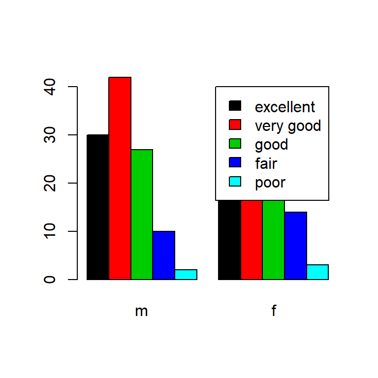

```r
barplot(hlth_table, beside=TRUE, col=1:5, legend.text=TRUE)
```

*Compare overall proportions on barplot*

```r
prop.table(hlth_table)
```

```
                      m           f
  excellent 0.136363636 0.136363636
  very good 0.190909091 0.150000000
  good      0.122727273 0.131818182
  fair      0.045454545 0.063636364
  poor      0.009090909 0.013636364
```

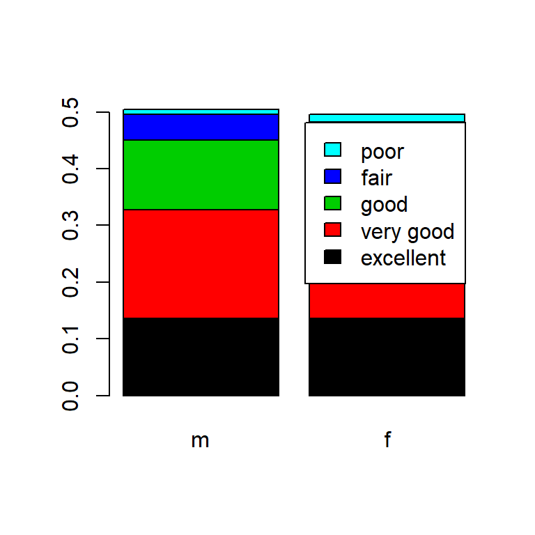

```r
barplot(prop.table(hlth_table), col=1:5, legend.text=TRUE)
```

*get proportions per gender*

```r
male_total <-sum(hlth_table[,"m"]) # sum of all rows in column 1 (m)
male_total
```

```
[1] 111
```

```r
male_vg_ex_prop <- sum(hlth_table[1:2,"m"])/male_total # proportion: sum/total
male_vg_ex_prop
```

```
[1] 0.6486486
```

```r
female_total <-sum(hlth_table[,"f"]) # sum of all rows in column 2 (f)
female_total
```

```
[1] 109
```

```r
female_vg_ex_prop <- sum(hlth_table[1:2,"f"])/female_total # proportion: sum/total
female_vg_ex_prop
```

```
[1] 0.5779817
```

*Q1(c) Use subset to extract the smokers.* *For the smokers, calculate the proportion of men that have health very good or better.* *Do the same for women.*

```r
head(cdc1)
```

```
        genhlth exerany hlthplan smoke100 height weight wtdesire age
5752       good     yes    cover    smoke     66    160      155  72
15766      fair     yes    cover    smoke     60    148      118  80
8179       fair      no    cover  nosmoke     65    173      170  48
17658 very good      no    cover    smoke     72    195      180  50
18806      good     yes    cover  nosmoke     67    165      135  35
911   excellent     yes    cover  nosmoke     60    103      103  33
      gender
5752       m
15766      f
8179       m
17658      m
18806      f
911        f
```

```r
smokers_table <- subset(cdc1, smoke100 == "smoke")
head(smokers_table)
```

```
        genhlth exerany hlthplan smoke100 height weight wtdesire age
5752       good     yes    cover    smoke     66    160      155  72
15766      fair     yes    cover    smoke     60    148      118  80
17658 very good      no    cover    smoke     72    195      180  50
17843      good      no    cover    smoke     65    130      120  39
11025      good      no    cover    smoke     76    290      230  53
19128 very good     yes    cover    smoke     66    150      150  56
      gender
5752       m
15766      f
17658      m
17843      f
11025      m
19128      f
```

*extract male smokers*

```r
healthy_male_smokers <- subset(smokers_table, gender == "m" & (genhlth == "excellent" | genhlth == "very good"))
head(healthy_male_smokers)
```

```
        genhlth exerany hlthplan smoke100 height weight wtdesire age
17658 very good      no    cover    smoke     72    195      180  50
12797 very good     yes    cover    smoke     74    205      195  55
14153 very good     yes  nocover    smoke     71    160      130  19
5776  very good     yes    cover    smoke     72    170      185  29
13793 very good      no    cover    smoke     74    350      185  28
15884 excellent      no    cover    smoke     66    155      115  77
      gender
17658      m
12797      m
14153      m
5776       m
13793      m
15884      m
```

```r
healthy_male_smokers <- subset(healthy_male_smokers, select = c(genhlth,smoke100,gender))
head(healthy_male_smokers)
```

```
        genhlth smoke100 gender
17658 very good    smoke      m
12797 very good    smoke      m
14153 very good    smoke      m
5776  very good    smoke      m
13793 very good    smoke      m
15884 excellent    smoke      m
```

```r
proportion_healthy_male_smokers <- length(healthy_male_smokers)/male_total
proportion_healthy_male_smokers
```

```
[1] 0.02702703
```

*extract female smokers*

```r
healthy_female_smokers <- subset(smokers_table, gender == "f" & (genhlth == "excellent" | genhlth == "very good"))
head(healthy_female_smokers)
```

```
        genhlth exerany hlthplan smoke100 height weight wtdesire age
19128 very good     yes    cover    smoke     66    150      150  56
841   excellent     yes    cover    smoke     63    115      113  52
6553  very good     yes    cover    smoke     61    140      135  87
17773 very good     yes    cover    smoke     62    115      110  33
15142 very good      no    cover    smoke     65    163      163  76
9298  excellent     yes    cover    smoke     68    160      160  81
      gender
19128      f
841        f
6553       f
17773      f
15142      f
9298       f
```

```r
healthy_female_smokers <- subset(healthy_female_smokers, select = c(genhlth,smoke100,gender))
healthy_female_smokers
```

```
        genhlth smoke100 gender
19128 very good    smoke      f
841   excellent    smoke      f
6553  very good    smoke      f
17773 very good    smoke      f
15142 very good    smoke      f
9298  excellent    smoke      f
2544  excellent    smoke      f
7568  excellent    smoke      f
13307 excellent    smoke      f
19615 very good    smoke      f
2926  excellent    smoke      f
19562 excellent    smoke      f
4748  excellent    smoke      f
1523  very good    smoke      f
16822 excellent    smoke      f
9876  very good    smoke      f
9966  excellent    smoke      f
19925 excellent    smoke      f
14803 excellent    smoke      f
12253 very good    smoke      f
5252  excellent    smoke      f
12281 very good    smoke      f
3378  very good    smoke      f
8091  excellent    smoke      f
```

```r
proportion_healthy_female_smokers <- length(healthy_female_smokers)/female_total
proportion_healthy_female_smokers
```

```
[1] 0.02752294
```

*(d) Repeat (c) for non smokers.*

```r
non_smokers_table <- subset(cdc1, smoke100 == "nosmoke")
head(non_smokers_table)
```

```
        genhlth exerany hlthplan smoke100 height weight wtdesire age
8179       fair      no    cover  nosmoke     65    173      170  48
18806      good     yes    cover  nosmoke     67    165      135  35
911   excellent     yes    cover  nosmoke     60    103      103  33
10559      good     yes    cover  nosmoke     63    156      140  80
9129  very good     yes    cover  nosmoke     67    134      139  29
9062  excellent     yes    cover  nosmoke     64    120      120  47
      gender
8179       m
18806      f
911        f
10559      f
9129       m
9062       f
```

*extract male non smokers*

```r
healthy_male_non_smokers <- subset(non_smokers_table, gender == "m" & (genhlth == "excellent" | genhlth == "very good"))
head(healthy_male_non_smokers)
```

```
        genhlth exerany hlthplan smoke100 height weight wtdesire age
9129  very good     yes    cover  nosmoke     67    134      139  29
13544 excellent     yes    cover  nosmoke     78    200      200  28
2939  excellent     yes    cover  nosmoke     69    220      200  26
19232 very good      no    cover  nosmoke     71    140      140  23
18019 very good     yes    cover  nosmoke     73    135      140  18
8274  very good      no    cover  nosmoke     68    230      180  23
      gender
9129       m
13544      m
2939       m
19232      m
18019      m
8274       m
```

```r
healthy_male_non_smokers <- subset(healthy_male_non_smokers, select = c(genhlth,smoke100,gender))
head(healthy_male_non_smokers)
```

```
        genhlth smoke100 gender
9129  very good  nosmoke      m
13544 excellent  nosmoke      m
2939  excellent  nosmoke      m
19232 very good  nosmoke      m
18019 very good  nosmoke      m
8274  very good  nosmoke      m
```

```r
proportion_healthy_male_non_smokers <- length(healthy_male_non_smokers)/male_total
proportion_healthy_male_non_smokers
```

```
[1] 0.02702703
```

```r
healthy_female_non_smokers <- subset(non_smokers_table, gender == "f" & (genhlth == "excellent" | genhlth == "very good"))
head(healthy_female_non_smokers)
```

```
        genhlth exerany hlthplan smoke100 height weight wtdesire age
911   excellent     yes    cover  nosmoke     60    103      103  33
9062  excellent     yes    cover  nosmoke     64    120      120  47
19072 very good      no  nocover  nosmoke     64    194      130  22
10868 excellent     yes    cover  nosmoke     65    120      116  35
9540  very good     yes    cover  nosmoke     69    190      160  34
4624  very good     yes    cover  nosmoke     61    105      105  48
      gender
911        f
9062       f
19072      f
10868      f
9540       f
4624       f
```

```r
healthy_female_non_smokers <- subset(healthy_female_non_smokers, select = c(genhlth,smoke100,gender))
healthy_female_non_smokers
```

```
        genhlth smoke100 gender
911   excellent  nosmoke      f
9062  excellent  nosmoke      f
19072 very good  nosmoke      f
10868 excellent  nosmoke      f
9540  very good  nosmoke      f
4624  very good  nosmoke      f
8258  very good  nosmoke      f
3043  very good  nosmoke      f
7468  excellent  nosmoke      f
12209 very good  nosmoke      f
2049  very good  nosmoke      f
3486  excellent  nosmoke      f
2603  excellent  nosmoke      f
11940 very good  nosmoke      f
```

[output cut: 25 more lines]

```r
proportion_healthy_female_non_smokers <- length(healthy_female_non_smokers)/female_total
proportion_healthy_female_non_smokers
```

```
[1] 0.02752294
```

*(e) Based on your calculations of (c) and (d), compare the health of men and women, and the* *health of smokers and non smokers.*

```r
proportion_healthy_male_smokers
```

```
[1] 0.02702703
```

```r
proportion_healthy_female_smokers
```

```
[1] 0.02752294
```

```r
proportion_healthy_male_non_smokers
```

```
[1] 0.02702703
```

```r
proportion_healthy_female_non_smokers
```

```
[1] 0.02752294
```